# Extracting component effects from network meta analysis: Power and bias

The goal here is to sketch out how we might simulate data for a network meta analysis, and then run a power analysis for variables of interest: for example, like the N studies included in the network, and also the number and overlap of components.

# Defining the population of studies

For the moment, we assume components of treatment A-Z, which are variously combined and then compared against a single control intervention:

## Intervention component effect sizes.

```r
set.seed(12345)

# these are the population effect sizes for each intervention
# nb Only A has an effect for the moment
txEffs <-  c(.5, .25, rep(0, length(LETTERS)-2)) #rnorm(length(LETTERS), .5, .5)
names(txEffs) <- LETTERS

population_treatment_modifier_mean = 0
population_treatment_modifier_sd = 0
```

Combinations of components:

```r
maxtx <- 3
maxctrl <- 1

txcombinations <- purrr::map(combn(c(names(txEffs[1:maxtx]), rep(NA, maxtx)), m=maxtx, simplify = F), .f = sort) %>%
  map(~paste0(., collapse = "")) %>% as_vector() %>% .[.!=""] %>% unique

# could vary this later
ctrlcombinations = "Z"

txcombinations
```

```
## [1] "ABC" "AB"  "AC"  "A"   "BC"  "B"   "C"
```

```r
ctrlcombinations
```

```
## [1] "Z"
```

This makes the full list of comparisons:

```r
network.comparisons_ <- crossing(   tx = txcombinations,
                            ctrl = ctrlcombinations) %>%
  mutate(comparison = factor(paste(tx, "vs", ctrl))) %>%
  rowwise() %>%
  mutate(tx_d = lookupd(tx)) %>%
  mutate(ctrl_d = lookupd(ctrl)) %>%
  mutate(d = tx_d - ctrl_d)  %>%
  ungroup()

txdummies  <- network.comparisons_ %>%
  distinct(tx) %>%
  group_by(tx) %>%
  do(., contains.tx(.$tx))

network.comparisons <- left_join(network.comparisons_, txdummies[,1:4]) %>%
  glimpse
```

```
## Observations: 7
## Variables: 9
## $ tx         <chr> "A", "AB", "ABC", "AC", "B", "BC", "C"
## $ ctrl       <chr> "Z", "Z", "Z", "Z", "Z", "Z", "Z"
## $ comparison <fct> A vs Z, AB vs Z, ABC vs Z, AC vs Z, B vs Z, BC vs Z...
## $ tx_d       <dbl> 0.50, 0.75, 0.75, 0.50, 0.25, 0.25, 0.00
## $ ctrl_d     <dbl> 0, 0, 0, 0, 0, 0, 0
## $ d          <dbl> 0.50, 0.75, 0.75, 0.50, 0.25, 0.25, 0.00
## $ txA        <lgl> TRUE, TRUE, TRUE, TRUE, FALSE, FALSE, FALSE
## $ txB        <lgl> FALSE, TRUE, TRUE, FALSE, TRUE, TRUE, FALSE
## $ txC        <lgl> FALSE, FALSE, TRUE, TRUE, FALSE, TRUE, TRUE
```

# Make population of studies which is later sampled-from for the meta analysis

```r
NSTUDIES <- 100 # per comparison... this is alots
NPERSTUDY <- 1000 # max N individuals within a study

network.studies <- network.comparisons %>%
  group_by(comparison) %>%
  do(., sample_n(., NSTUDIES, replace=T)) %>%
  ungroup() %>%
  mutate(study=row_number())

network.ipd <- network.studies %>%
  tidyr::expand(select(., everything()), participant = 0:NPERSTUDY, treated = 0:1) %>%
  group_by(study, treated) %>%
  mutate(y = rnorm(n(), d*treated, 1)) %>%
  glimpse
```

```
## Observations: 1,401,400
## Variables: 13
## $ tx          <chr> "A", "A", "A", "A", "A", "A", "A", "A", "A", "A", ...
## $ ctrl        <chr> "Z", "Z", "Z", "Z", "Z", "Z", "Z", "Z", "Z", "Z", ...
## $ comparison  <fct> A vs Z, A vs Z, A vs Z, A vs Z, A vs Z, A vs Z, A ...
## $ tx_d        <dbl> 0.5, 0.5, 0.5, 0.5, 0.5, 0.5, 0.5, 0.5, 0.5, 0.5, ...
## $ ctrl_d      <dbl> 0, 0, 0, 0, 0, 0, 0, 0, 0, 0, 0, 0, 0, 0, 0, 0, 0,...
## $ d           <dbl> 0.5, 0.5, 0.5, 0.5, 0.5, 0.5, 0.5, 0.5, 0.5, 0.5, ...
## $ txA         <lgl> TRUE, TRUE, TRUE, TRUE, TRUE, TRUE, TRUE, TRUE, TR...
## $ txB         <lgl> FALSE, FALSE, FALSE, FALSE, FALSE, FALSE, FALSE, F...
## $ txC         <lgl> FALSE, FALSE, FALSE, FALSE, FALSE, FALSE, FALSE, F...
## $ study       <int> 1, 1, 1, 1, 1, 1, 1, 1, 1, 1, 1, 1, 1, 1, 1, 1, 1,...
## $ participant <int> 0, 0, 1, 1, 2, 2, 3, 3, 4, 4, 5, 5, 6, 6, 7, 7, 8,...
## $ treated     <int> 0, 1, 0, 1, 0, 1, 0, 1, 0, 1, 0, 1, 0, 1, 0, 1, 0,...
## $ y           <dbl> 0.29294030, -0.79897047, -0.08670791, -0.94740649,...
```

Check the effects look right

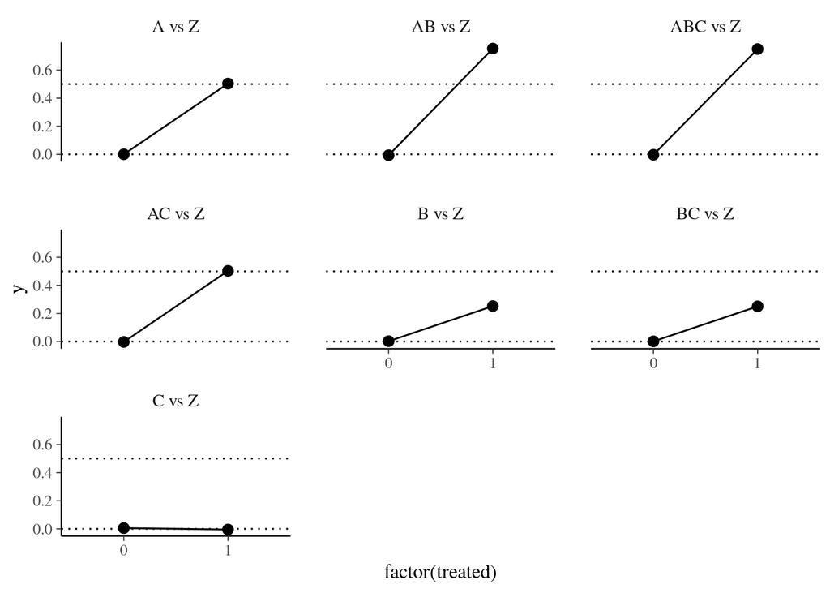

```r
network.ipd %>%
  ggplot(aes(factor(treated), y, group=comparison)) +
  stat_summary(fun.data = mean_cl_normal, geom="line") +
  stat_summary(fun.data = mean_cl_normal, geom="pointrange") +
  geom_hline(yintercept = c(0,.5), linetype="dotted") + facet_wrap(~comparison)
```

# Sample from the population of studies

That is, sample both studies and individuals within studies (to simulate that studies vary in size)

```r
#set.seed(12345)
# let's say we found 20 or 100 published studies
N_STUDY_SAMPLED <- 100

# see below... study size is cauchy distributed, which may not be sensible, but it's not normal
ARM_N_MEAN <- 80
network.ipd$study %>% unique %>% length
```

```
## [1] 700
```

```r
# N_COMPARISONS <- network.comparisons$tx %>% unique %>% length
# MISSING_COMPARISONS <- c("A", "C") # both against Z
studysubset <- sample(network.ipd$study %>% unique, size=N_STUDY_SAMPLED, replace=F)

# hist(rcauchy(30, location = 100, scale = 15) %>% .[.>20])
network.ipd.sample <- network.ipd %>%
  filter(study %in% studysubset) %>%
  group_by(study) %>%
  do(., top_n(., n=min(1000, max(20, round(rcauchy(1, 100, 20), 0))), wt=runif(n())) ) %>%
  ungroup() %>%
  glimpse
```

```
## Observations: 12,276
## Variables: 13
## $ tx          <chr> "A", "A", "A", "A", "A", "A", "A", "A", "A", "A", ...
## $ ctrl        <chr> "Z", "Z", "Z", "Z", "Z", "Z", "Z", "Z", "Z", "Z", ...
## $ comparison  <fct> A vs Z, A vs Z, A vs Z, A vs Z, A vs Z, A vs Z, A ...
## $ tx_d        <dbl> 0.5, 0.5, 0.5, 0.5, 0.5, 0.5, 0.5, 0.5, 0.5, 0.5, ...
## $ ctrl_d      <dbl> 0, 0, 0, 0, 0, 0, 0, 0, 0, 0, 0, 0, 0, 0, 0, 0, 0,...
## $ d           <dbl> 0.5, 0.5, 0.5, 0.5, 0.5, 0.5, 0.5, 0.5, 0.5, 0.5, ...
## $ txA         <lgl> TRUE, TRUE, TRUE, TRUE, TRUE, TRUE, TRUE, TRUE, TR...
## $ txB         <lgl> FALSE, FALSE, FALSE, FALSE, FALSE, FALSE, FALSE, F...
## $ txC         <lgl> FALSE, FALSE, FALSE, FALSE, FALSE, FALSE, FALSE, F...
## $ study       <int> 5, 5, 5, 5, 5, 5, 5, 5, 5, 5, 5, 5, 5, 5, 5, 5, 5,...
## $ participant <int> 3, 4, 7, 9, 9, 21, 26, 27, 28, 29, 38, 39, 42, 44,...
## $ treated     <int> 1, 1, 1, 0, 1, 0, 1, 1, 0, 0, 0, 1, 1, 1, 1, 0, 0,...
## $ y           <dbl> 1.23137209, 0.30441272, 0.67444738, -0.62384678, 0...
```

```r
network.ipd.sample %>%
  group_by(study, treated) %>%
  summarise(n=n()) %>%
  glimpse
```

```
## Observations: 200
## Variables: 3
## $ study   <int> 5, 5, 7, 7, 30, 30, 40, 40, 48, 48, 80, 80, 89, 89, 90...
## $ treated <int> 0, 1, 0, 1, 0, 1, 0, 1, 0, 1, 0, 1, 0, 1, 0, 1, 0, 1, ...
## $ n       <int> 215, 194, 52, 65, 87, 71, 47, 48, 41, 40, 67, 55, 45, ...
```

# IPD meta analysis

First, run simple `lm` within each study to calculate summary data (i.e. between groups diff and std error)

```r
network.ipd.sample.summary <- network.ipd.sample %>%
  group_by(study) %>%
  do(., {lm(y~treated, data=.) %>% tidy() %>% filter(term=="treated")}) %>%
  select(study, estimate, std.error) %>%
  glimpse
```

```
## Observations: 100
## Variables: 3
## $ study     <int> 5, 7, 30, 40, 48, 80, 89, 90, 96, 114, 118, 132, 140...
## $ estimate  <dbl> 0.53074894, 0.35783191, 0.44517115, 0.40097163, 0.38...
## $ std.error <dbl> 0.0928425, 0.1917095, 0.1401096, 0.2107119, 0.220579...
```

Forest-type plot

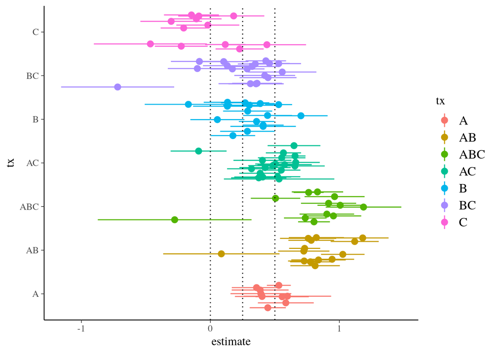

```r
left_join(network.ipd.sample.summary, network.studies %>% select(study, tx)) %>%
  ggplot(aes(tx, y=estimate, color=tx,
             ymin=estimate-std.error, ymax=estimate+std.error )) +
  geom_pointrange(position="jitter") +
  geom_hline(yintercept = c(0,.25,.5), linetype="dotted") + coord_flip()
```

## Fitting an PD model

```r
ipd.lmer <- m1 <- stan_lmer(y ~ 0+treated*tx + (1|study), data=network.ipd.sample)
ipd.lmer
```

```
## stan_lmer
##  family:       gaussian [identity]
##  formula:      y ~ 0 + treated * tx + (1 | study)
##  observations: 12276
## ------
##               Median MAD_SD
## treated        0.5    0.1
## txA            0.0    0.0
## txAB           0.0    0.0
## txABC          0.0    0.0
## txAC           0.0    0.0
## txB            0.0    0.0
## txBC           0.0    0.0
## txC            0.0    0.0
## treated:txAB   0.4    0.1
## treated:txABC  0.3    0.1
## treated:txAC   0.0    0.1
## treated:txB   -0.1    0.1
## treated:txBC  -0.2    0.1
## treated:txC   -0.5    0.1
## sigma          1.0    0.0
##
## Error terms:
##  Groups   Name        Std.Dev.
##  study    (Intercept) 0.039
##  Residual             1.003
## Num. levels: study 100
##
## Sample avg. posterior predictive distribution of y:
##          Median MAD_SD
## mean_PPD 0.2    0.0
##
## ------
## For info on the priors used see help('prior_summary.stanreg').
```

## Simulating

```r
nd <- network.comparisons %>%
  filter(tx=="A"|tx=="B"|tx=="C") %>%
  select(tx, txA,txB,txC) %>%
  tidyr::expand(select(., everything()), treated=0:1) %>% mutate(study=Inf)


a.b.c.diffs <- tidybayes::add_fitted_samples(nd, ipd.lmer) %>%
  data.table::dcast(.iteration+tx~treated, value.var="estimate") %>%
  mutate(d = `0`-`1`) %>%
  data.table::dcast(.iteration~tx, value.var="d") %>%
  mutate(AB = A-B, AC = A-C, BC = B-C) %>%
  glimpse
```

```
## Observations: 4,000
## Variables: 7
## $ .iteration <int> 1, 2, 3, 4, 5, 6, 7, 8, 9, 10, 11, 12, 13, 14, 15, ...
## $ A          <dbl> -0.5883323, -0.5907717, -0.5114786, -0.4258626, -0....
## $ B          <dbl> -0.2745638, -0.3467963, -0.3630517, -0.3160898, -0....
## $ C          <dbl> 0.061899448, 0.050879373, 0.071453988, -0.052342258...
## $ AB         <dbl> -0.31376849, -0.24397534, -0.14842689, -0.10977279,...
## $ AC         <dbl> -0.6502317, -0.6416510, -0.5829326, -0.3735203, -0....
## $ BC         <dbl> -0.3364632, -0.3976757, -0.4345057, -0.2637475, -0....
```

## True tx effects:

Differences should be AC = .5, AB or BC = .25

```r
network.comparisons %>%
  filter(tx=="A"|tx=="B"|tx=="C") %>%
  select(tx, tx_d)
```

| tx | tx_d |
| --- | --- |
| A | 0.50 |
| B | 0.25 |
| C | 0.00 |

## Recovered individual treatment comparisons

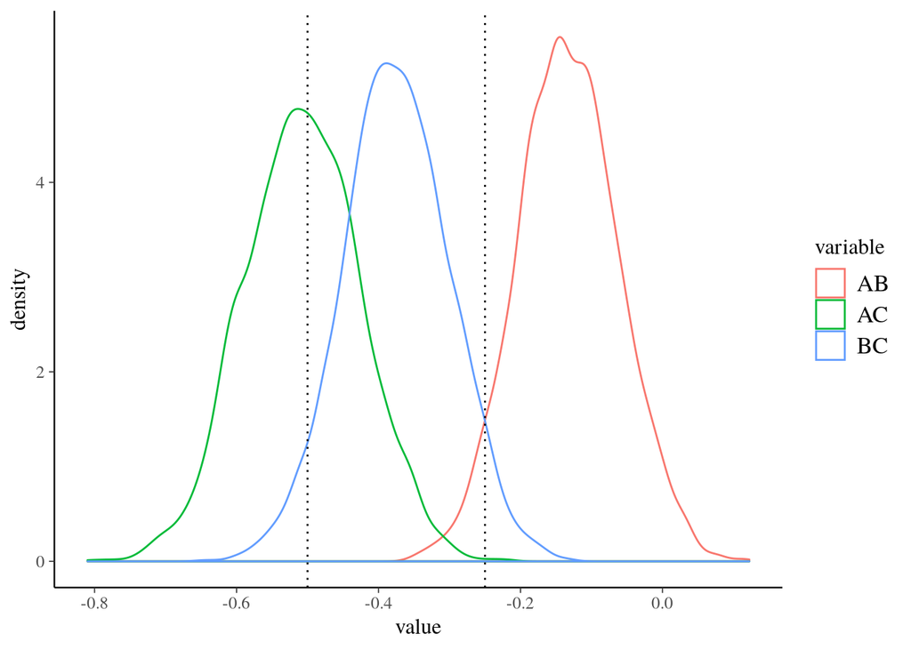

```r
a.b.c.diffs %>%
  select(AB, AC, BC) %>%
  data.table::melt() %>%
  ggplot(aes(value, color=variable)) +
  geom_density() +
  geom_vline(xintercept = c(-.25,-.5), linetype="dotted")
```

In tabular form

```r
a.b.c.diffs %>%
  select(AB, AC, BC) %>%
  data.table::melt() %>%
  group_by(variable) %>%
  tidybayes::median_qi(value)
```

| variable | value | conf.low | conf.high | .prob |
| --- | --- | --- | --- | --- |
| AB | -0.1344524 | -0.2691737 | 0.00711322 | 0.95 |
| AC | -0.5072558 | -0.6632554 | -0.34950208 | 0.95 |
| BC | -0.3757157 | -0.5212871 | -0.23067060 | 0.95 |

Need to check this..

```r
a.b.c.diffs %>%
  select(AB, AC, BC) %>%
  brms::hypothesis(c("AB > BC", "AC < AB"))
```

```
## Hypothesis Tests for class :
##      Hypothesis Estimate Est.Error CI.Lower CI.Upper Evid.Ratio Post.Prob
## 1 (AB)-(BC) > 0     0.24      0.12     0.04      Inf      42.01      0.98
## 2 (AC)-(AB) < 0    -0.37      0.07     -Inf    -0.25        Inf      1.00
##   Star
## 1    *
## 2    *
## ---
## '*': The expected value under the hypothesis lies outside the 95%-CI.
## Posterior probabilities of point hypotheses assume equal prior probabilities.
```

## Ranked treatments

```r
tx.rankings <- tidybayes::add_fitted_samples(nd, ipd.lmer) %>%
  data.table::dcast(.iteration+tx~treated, value.var="estimate") %>%
  mutate(d = `0`-`1`) %>%
  group_by(.iteration) %>%
  arrange(-d) %>%
  mutate(r = row_number()) %>%
  group_by(.iteration) %>%
  summarise(rank = paste(tx, collapse="<"))

tx.rankings %>% group_by(rank) %>% count() %>% mutate(percent=n/4000 * 100)
```

| rank | n | percent |
| --- | --- | --- |
| C<A<B | 133 | 3.325 |
| C<B<A | 3867 | 96.675 |

# From summary data

```r
# don't need this here, but would with real data
ctrl.sd <- network.ipd %>% filter(treated==0) %>% pull(y) %>% sd(.)

network.ipd.sample.summary.z <- network.ipd.sample.summary %>%
  mutate(estimate = estimate/ctrl.sd)

mreg.data <- network.ipd.sample.summary.z %>%
  left_join(network.studies %>% select(study, starts_with("tx")))
```

## Random effects model

i.e. random effect between studies

```r
#meta.fixed <- brm(estimate | se(std.error) ~ 1, data = mreg.data)
#meta.random <- brm(estimate | se(std.error) ~ 1 + (1|study), data = mreg.data)
metareg.random <- brm(estimate | se(std.error) ~ 0 + tx + (1|study), data = mreg.data)
```

Individual effects of A vs B vs C are reasonably well extracted… although B !=.25 and this was a large sample, so perhaps need to check in sims:

```r
metareg.random
```

```
##  Family: gaussian
##   Links: mu = identity; sigma = identity
## Formula: estimate | se(std.error) ~ 0 + tx + (1 | study)
##    Data: mreg.data (Number of observations: 100)
## Samples: 4 chains, each with iter = 2000; warmup = 1000; thin = 1;
##          total post-warmup samples = 4000
##
## Group-Level Effects:
## ~study (Number of levels: 100)
##               Estimate Est.Error l-95% CI u-95% CI Eff.Sample Rhat
## sd(Intercept)     0.03      0.02     0.00     0.09       1354 1.00
##
## Population-Level Effects:
##       Estimate Est.Error l-95% CI u-95% CI Eff.Sample Rhat
## txA       0.48      0.06     0.36     0.60       4000 1.00
## txAB      0.83      0.05     0.74     0.93       4000 1.00
## txABC     0.82      0.05     0.71     0.93       4000 1.00
## txAC      0.52      0.04     0.44     0.60       4000 1.00
## txB       0.35      0.05     0.25     0.43       4000 1.00
## txBC      0.30      0.05     0.20     0.39       4000 1.00
## txC      -0.04      0.06    -0.15     0.08       4000 1.00
##
## Samples were drawn using sampling(NUTS). For each parameter, Eff.Sample
## is a crude measure of effective sample size, and Rhat is the potential
## scale reduction factor on split chains (at convergence, Rhat = 1).
```

# Next steps…

Simulation which:

- reduces the (study) sample size
- makes study size distribution more realistic … cauchy? t?
- varies population severity/responsiveness
- eliminates network paths or independent evaluations and uses the equivalence equations (see welton paper)
- imagines more components in the network, with more overlap (and fewer individual evaluations)
- uses active interventions as controls
- varies control effectiveness
- introduces confounding… e.g. association between treatments and control effectiveness
- samples from heterogenous effect sizes… i.e. situation when theta not fixed across studies

In terms of models:

- Think more about model priors
- parameterisation? Are we equivalent to the common BUGS models?

Won’t do

- binary outcomes; stick with continuous?
- twice-removed comparisons? I.e. distant comparisons in a large network